# Example P.1 Organ Donation

Last updated Tuesday, October 03, 2023 @ 12:09 AM

## Before We Begin…

These slides are intended to accompany Section P.1 Introduction to the Six-Step Method in [*Introduction to Statistical Investigations, 2nd Edition*](http://www.isi-stats.com/isi/index2nd.html).

*This content does not replace reading the textbook section.* It is for class presentation and reference.

See also:

- Glossary of ISI Textbook Vocabulary on AsULearn
- [Section P.1 Introduction to the Six-Step Method](https://stat-jet-asu.github.io/STT1810BasicStatistics/Slides/CHP_1.html)

## The Spiral Approach to Investigation

- Statistical investigations typically include these six steps in some form.
- These six steps may not always be followed in this exact order, but a good statistical investigation will go through all these steps before completion.
- The findings of one study typically will generate new research questions; that’s how science works!

## STEP 1: Ask a Research Question

**General Question:** Can we find a way to increase the likelihood that a person agrees to become an organ donor?

However, this question is simply too broad to design a study for. We need to focus it more into a question about which we could reasonably collect data to produce an answer.

Consider: In the United States, everyone 18 years of age or older is eligible to register as an organ donor on their driver’s license. What is the *process* of asking people to be donors?

**Research Question:** Does the default option that is presented to driver’s license applicants influence the likelihood that a person will choose to become an organ donor?

[*The research question influences our study design and hypotheses.*]

## STEP 2: Design a Study / Collect Data

Researchers recruited participants using online forums and asked them to pretend to apply for a new driver’s license. The participants did not know in advance that organ donation was the main focus of the study or that different options would be given to the respondents.

They offered participants $4.00 to complete an online survey. After the results were collected, the researchers removed data that came from multiple responses from the same IP address, surveys completed in less than five seconds, and respondents whose residential address could not be verified.

*Can you think of any potential problems with this methodology that might affect the results of the study? What are some positive aspects of this design? [We will learn about study design in Chapter 4.]*

## Organ Donation Options

The participants were asked to imagine they have moved to a new state and are applying for a driver’s license. As part of this application, they were to decide whether or not to become an organ donor. Each person was given one of three choices.

- The default option in the application was *not* to be a donor; participants had to choose to become a donor if they wished (the *opt-in* group).
- The default option in the application was to be a donor; thus, they had to choose *not* to become a donor if they wished (the *opt-out* group).
- No default option in the application; people had to choose to become a donor or not become a donor (the *neutral* group).

## Additional Design Details

observational units

- 161 recruited volunteers

explanatory variable

- default donation option (categorical, three treatments)

response variable

- choice to be an organ donor or not (categorical, binary)

study design

- randomized experiment (*assuming participants were randomly assigned to the three donation options*)

## STEP 3: Explore the Data

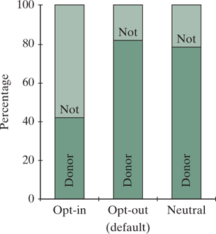

Who agreed to become donors?

- 41.8% of the opt-in group
- 82.0% of the opt-out group
- 78.6% of the neutral group

The neutral and opt-out conditions yielded higher percentages of organ donors than the opt-in condition.

- 82.0 / 41.8 ≈ 2 → twice as likely to agree to become a donor
- 78.6 / 41.8 ≈ 1.88 → 1.88 times (*almost twice*) as likely to agree

[*We will explore segmented bar graphs and risk ratios in Chapter 5.*]

## STEP 4: Draw Inferences

Using methods that we will learn in this course, the researchers analyzed whether the observed differences between the groups were large enough to show that the type of default option had a genuine effect. Then they estimated the size of that effect.

This study reported strong evidence that the neutral and opt-out versions produced a higher chance of a person choosing to be a donor, as compared to the opt-in version used by many states. [*We will learn about strength of evidence in Chapter 1.*]

Given the sample percentages and the sample size, they could be confident that the neutral version increases the chances a person agrees to be a donor by somewhere between 20% and 54%. [*We will learn about estimation in Chapter 3.*]

## STEP 5: Formulate Conclusions

In this study, participants given the “opt-in” strategy were much less likely than others to agree to become donors.

The researchers concluded that their data “suggest changes in defaults could increase donations in the [U.S.] of additional thousands of donors a year.”

[*We will learn more about making generalizations in Chapter 2 and cause-and-effect conclusions in Chapter 4.*]

Johnson, Eric J. and Goldstein, Daniel G., Do Defaults Save Lives? (Nov 21, 2003). *Science*, Vol. 302, pp. 1338-1339. Available SSRN: https://ssrn.com/abstract=1324774

## STEP 6: Look Back and Ahead

One study limitation is that participants were asked to *imagine* how they would respond; this might not reflect real behavior.

A new study might look at actual responses to questions about donation or monitor rates for states that adopt a new policy.

Researchers could examine whether giving educational material on organ donation might increase willingness to donate.

Another possible improvement would be to include participants from wider demographic groups than these volunteers.

Part of looking back also considers how a study relates to other similar studies that have been conducted previously.

## Looking Ahead: Variation in Data

ATS (access to transplant) score indicates a waitlist candidate’s likelihood of receiving a deceased donor transplant in the U.S. Variation in the scores reflects the equity (fairness) of the the allocation system. *Less* variation means *more* equity — chances are more alike across all candidates We will learn about SD in Section P.2. (Source: [OTPN / UNOS](https://insights.unos.org/equity-in-access/))

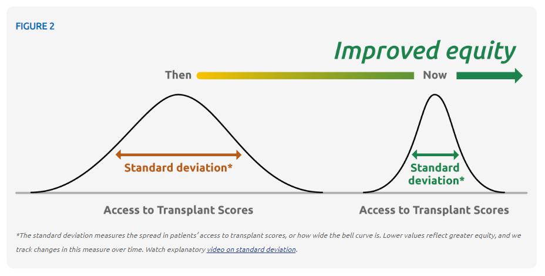